# Spotify daily top 200 songs

10 11 2021

On this chapter I will explore the following dataset available on kaggle:

- [Spotify daily top 200 songs with genres 2017-2021](https://www.kaggle.com/ivannatarov/spotify-daily-top-200-songs-with-genres-20172021)

It contains information on the daily top 200 tracks listened to by users of the Spotify digital platform around the world.

Here a quick glance at the data as is:

| Position | Track.Name | Artist | Streams | Date | Genre |
| --- | --- | --- | --- | --- | --- |
| 1 | Starboy | The Weeknd | 3135625 | 2017-01-01 | [‘canadian pop’, ‘canadian contemporary r&b’, ‘pop’] |
| 2 | Closer | The Chainsmokers | 3015525 | 2017-01-01 | [‘pop’, ‘pop dance’, ‘tropical house’, ‘edm’, ‘electropop’, ‘dance pop’] |
| 3 | Let Me Love You | DJ Snake | 2545384 | 2017-01-01 | [‘pop’, ‘electronic trap’, ‘dance pop’, ‘edm’, ‘pop dance’, ‘pop rap’] |
| 4 | Rockabye (feat. Sean Paul & Anne-Marie) | Clean Bandit | 2356604 | 2017-01-01 | [‘pop’, ‘uk dance’, ‘dance pop’, ‘uk funky’, ‘tropical house’, ‘pop dance’, ‘post-teen pop’, ‘edm’] |
| 5 | One Dance | Drake | 2259887 | 2017-01-01 | [‘toronto rap’, ‘canadian pop’, ‘canadian hip hop’, ‘rap’, ‘pop rap’, ‘hip hop’] |
| 6 | Fake Love | Drake | 2137437 | 2017-01-01 | [‘toronto rap’, ‘canadian pop’, ‘canadian hip hop’, ‘rap’, ‘pop rap’, ‘hip hop’] |

**Note:** For this exercise 2021 will not be included, as the year had not ended when closing this page.

## First impressions

The amount of streams has been increasing over the years as willingnes to pay for the service also increases and anti-piracy measures are being enforced in most countries.

We see more artists reaching the top 200, always with many cool songs to move us.

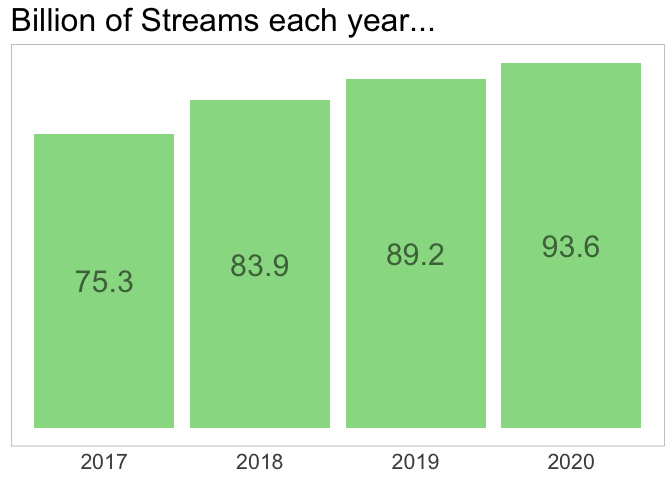

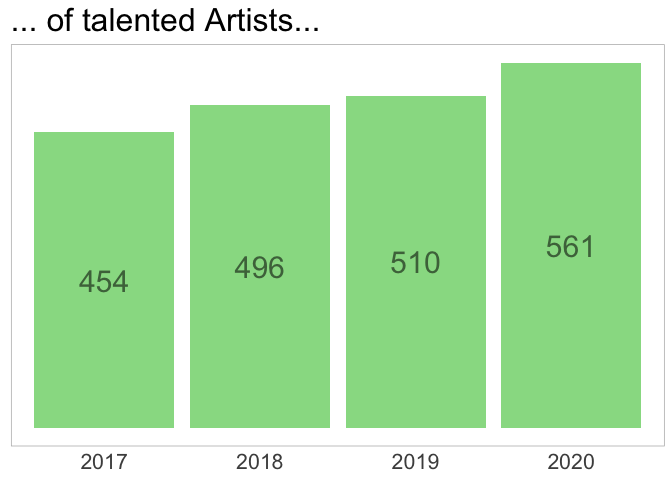

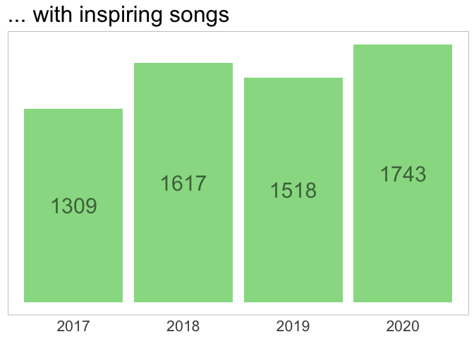

These artists made it to the top 3 of each year

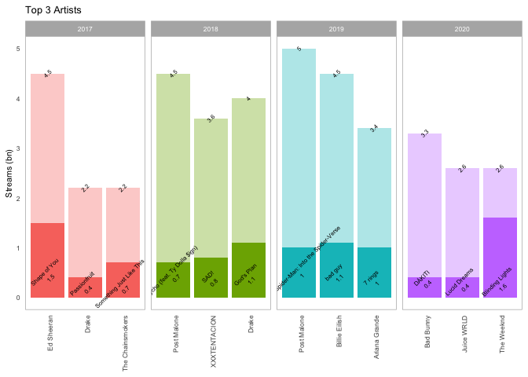

## Genres in a cloud

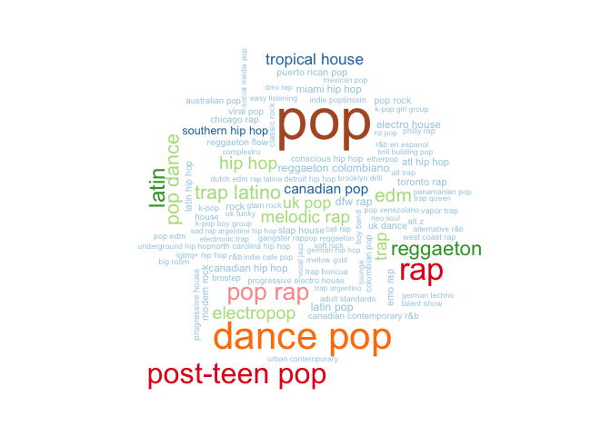

It’s hard to see the forest for the trees, so let’s pick the top 3 Genres for each year

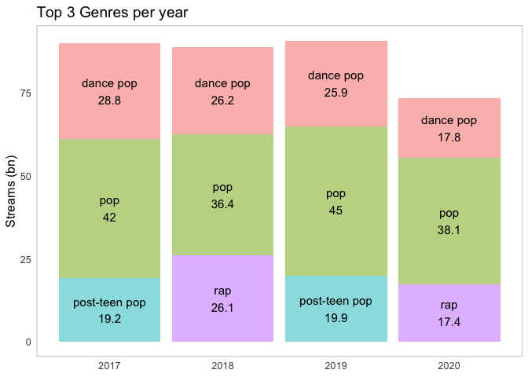

## What else?

### Extending the dataset

#### Scraping the web

I realised in the dataset there was no indication to the duration of the track, so I decided to write a little webscraping code to get this info from the Last.fm database.

Here the code I wrote if you’re into techy stuff. If not, just scroll down =P

```r
# Import the necessary libraries
library(rvest)
library(dplyr)
library(stringr)

# Get the Track and Artists names
DurationList <- unique(spotify[c("Track.Name","Artist")])
DurationList$Duration <-  0

# Replace some characters
DurationList$Track.Name <- str_replace_all(DurationList$Track.Name, " ", "+")
DurationList$Artist <- str_replace_all(DurationList$Artist, " ", "+")
DurationList$Track.Name <- str_replace_all(DurationList$Track.Name,"'","%27")
DurationList$Track.Name <- str_replace_all(DurationList$Track.Name,"\"","%28")

# Run over the Last.fm search pages and retrieve the Duration of each Track
for (i in 1:5149){
  tryCatch({
    link = paste0("https://www.last.fm/search?q=", DurationList[i,1], "+", DurationList[i,2])
    page = read_html(link)
    DurationList[i,3] <- page %>% html_nodes(".chartlist-duration") %>% .[1] %>% html_text() %>%
      str_replace_all(" ", "") %>% str_replace_all("\\n", "")
    print(paste0(i, " ",DurationList[i,2], " ",DurationList[i,1]," ", DurationList[i,3]))
  }, error = function(e){cat("ERROR :",conditionMessage(e), "\n")})
}

# Get the duration in seconds as the mm:ss format wouldn't allow for calculations
DurationList$DurationSec <- str_split(DurationList$Duration, pattern = ":", simplify = TRUE)
DurationList$DurationSec <- as.numeric(DurationList$DurationSec[,1])*60 + as.numeric(DurationList$DurationSec[,2])

# Now revert the character replacements
DurationList$Track.Name <- str_replace_all(DurationList$Track.Name, "\\+", " ")
DurationList$Artist <- str_replace_all(DurationList$Artist, "\\+", " ")
DurationList$Track.Name <- str_replace_all(DurationList$Track.Name,"%27","'")
DurationList$Track.Name <- str_replace_all(DurationList$Track.Name,"%28","\"")

# Then expand the original dataset by joining with the newly harvested data
tempos <- left_join(spotify,lista, by=c("Track.Name", "Artist"))
# Remove some of the NAs from the scraping
tempos <- tempos[!is.na(tempos$DurationSec),]
```

and here a glance at the final result

| Position | Track.Name | Artist | Streams | Date | Genre | Year | Month | Duration | DurationSec |
| --- | --- | --- | --- | --- | --- | --- | --- | --- | --- |
| 1 | Starboy | The Weeknd | 3135625 | 2017-01-01 | [‘canadian pop’, ‘canadian contemporary r&b’, ‘pop’] | 2017 | 1 | 3:50 | 230 |
| 2 | Closer | The Chainsmokers | 3015525 | 2017-01-01 | [‘pop’, ‘pop dance’, ‘tropical house’, ‘edm’, ‘electropop’, ‘dance pop’] | 2017 | 1 | 4:06 | 246 |
| 3 | Let Me Love You | DJ Snake | 2545384 | 2017-01-01 | [‘pop’, ‘electronic trap’, ‘dance pop’, ‘edm’, ‘pop dance’, ‘pop rap’] | 2017 | 1 | 3:25 | 205 |
| 4 | Rockabye (feat. Sean Paul & Anne-Marie) | Clean Bandit | 2356604 | 2017-01-01 | [‘pop’, ‘uk dance’, ‘dance pop’, ‘uk funky’, ‘tropical house’, ‘pop dance’, ‘post-teen pop’, ‘edm’] | 2017 | 1 | 4:10 | 250 |
| 5 | One Dance | Drake | 2259887 | 2017-01-01 | [‘toronto rap’, ‘canadian pop’, ‘canadian hip hop’, ‘rap’, ‘pop rap’, ‘hip hop’] | 2017 | 1 | 2:54 | 174 |
| 6 | Fake Love | Drake | 2137437 | 2017-01-01 | [‘toronto rap’, ‘canadian pop’, ‘canadian hip hop’, ‘rap’, ‘pop rap’, ‘hip hop’] | 2017 | 1 | 3:27 | 207 |

### Songs that won’t last forever

So now let’s check the newly acquired values and how they relate to the other variables.

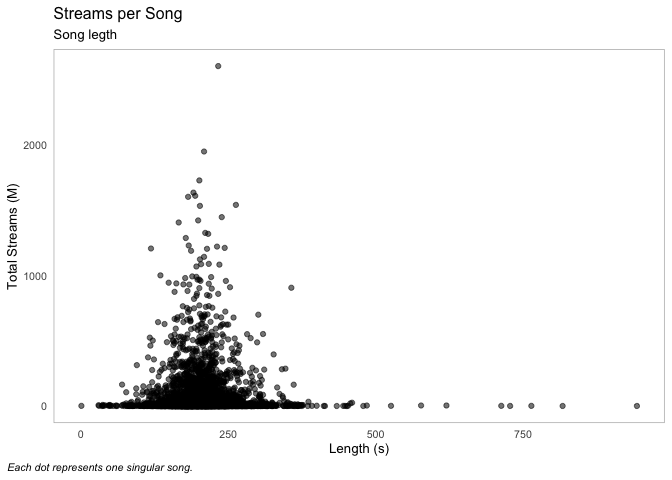

That looks quite cluttered, so let’s build a quick histogram to see how many times a given track length occurs in the new dataset.

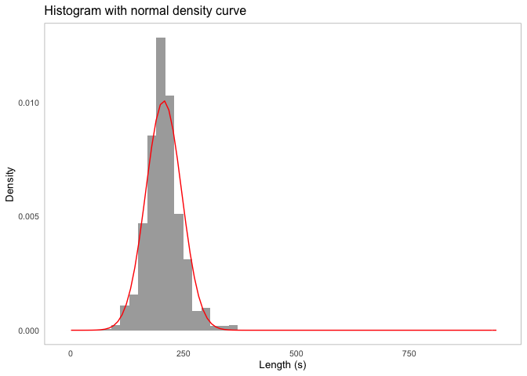

It may be interesting to break down the density per year.

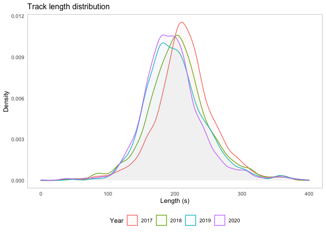

Looks like the average track length has been decreasing in the year on year comparison, the following boxplots may make it clearer:

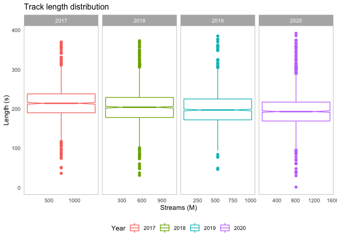

An here the explicit year on year decrease in the average length of the tracks:

[output not shown]

So all in all, we have more songs in the daily Top 200 streamed songs on Spotify, however the average duration has been shrinking over the past four years.

### What are the odds?

Only 1.05 % of the songs make it to the very top, and 8.39 % enter the top 10. But does it relate in any way with the length of the track? Looking at the charts below, seems plausible to assume that.

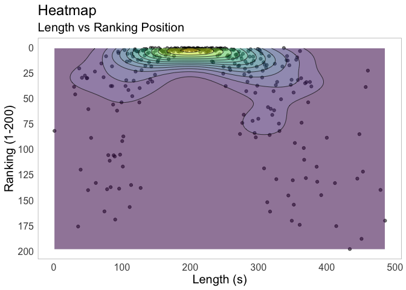

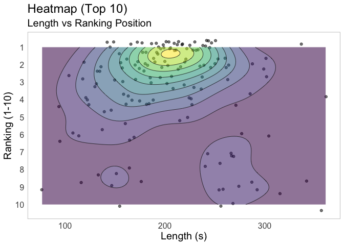

Hope you enjoyed this overview. The code used for building this report can be found on my [GitHub](https://github.com/AllysonAOdS/SpotifyTop200).